# Time Series: AR, MA, ARMA

### **NOTES ON STATISTICS, PROBABILITY and MATHEMATICS**

### Time Series Analysis From Plots:

From [this youtube post](https://www.youtube.com/watch?v=-vSzKfqcTDg). Also, [here is a more extensive document with simulations](https://drive.google.com/file/d/0Bwl-HpVJ_5PeSDdnX3lEWENidE0/view?usp=sharing) found online.

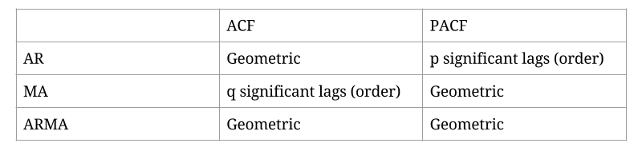

Examples:

#### Moving Average MA(1):

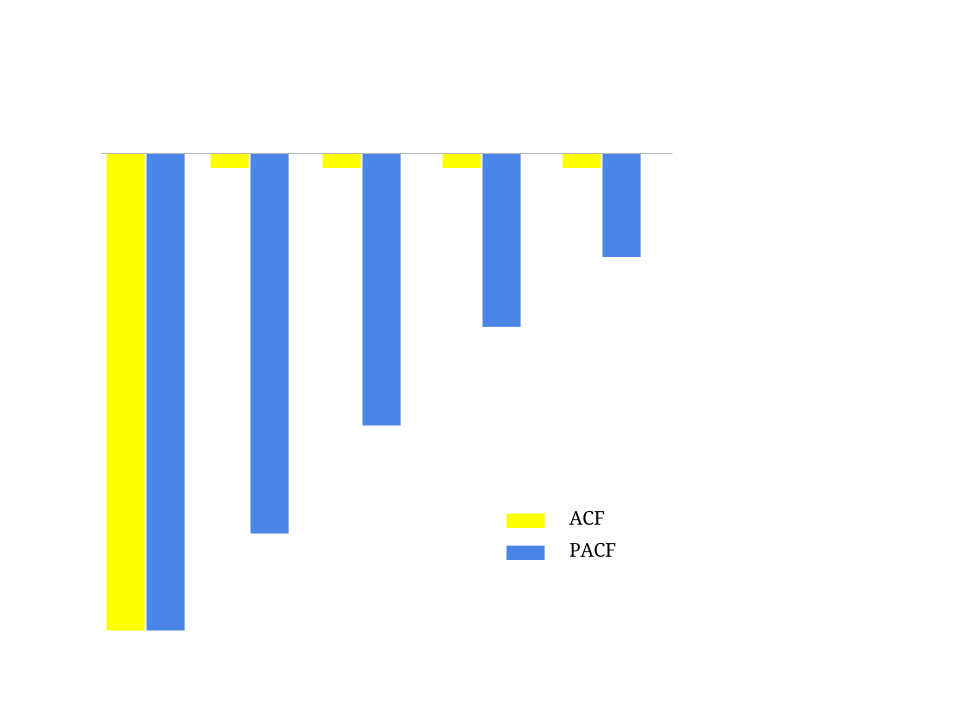

On this plot the ACF is significant only once (in reality the first entry in the ACF is always significant, since there is no lag in the first entry - it’s the correlation with itself), while the PACF is geometric. Hence it is an MA(1) process.

The negative values in the plot respond to a process of the form $\large\color{blue} {y_t} = k - \color{red}{\theta}\,\epsilon_{t-1}+\epsilon_t.$

Here is a simulation of an MA(1) process with $\theta = - 0.7:$

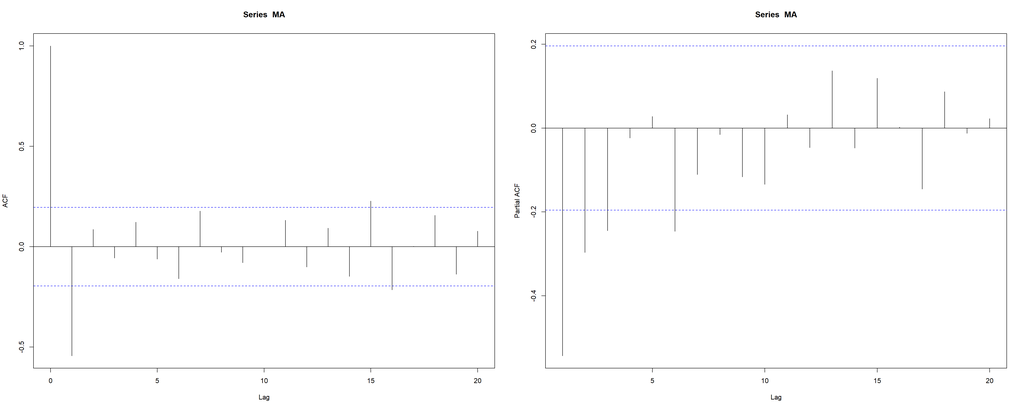

```r
set.seed(2017)
MA = arima.sim(model=list(ma = - 0.7), n = 100)
par(mfrow = c(1,2)); acf(MA); pacf(MA)
```

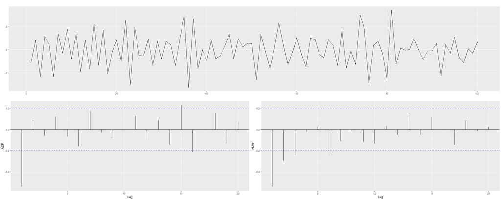

```r
par(mfrow=c(1,1))
library(ggplot2)
library(fpp2)
ggtsdisplay(MA)
```

#### Moving Average MA(2):

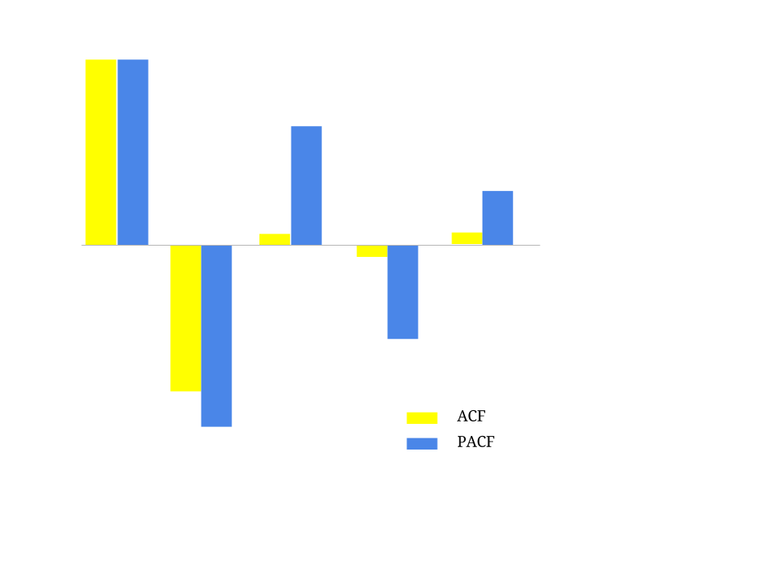

In this example the ACF is significant in the first and second lags, while the PACF follows a geometric decay. It is again a MA process, but this time an MA(2) of the form: $\large\color{blue} {y_t} = k+ \color{red}{\theta_1}\,\epsilon_{t-1}-\color{red}{\theta_2}\,\epsilon_{t-2}+\epsilon_t.$

Here’s an R simulation with $\theta_1 = 0.9$ and $\theta_2= -0.2:$

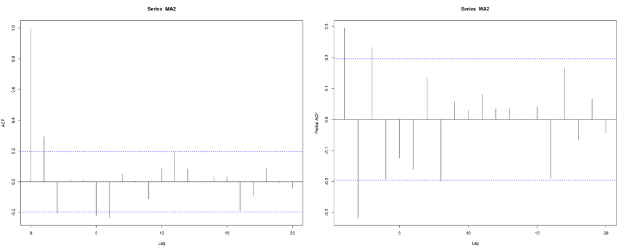

```r
set.seed(2017)
MA2 = arima.sim(list(ma= c(0.9, - 0.2)), n = 100)
par(mfrow = c(1,2));acf(MA2);pacf(MA2)
```

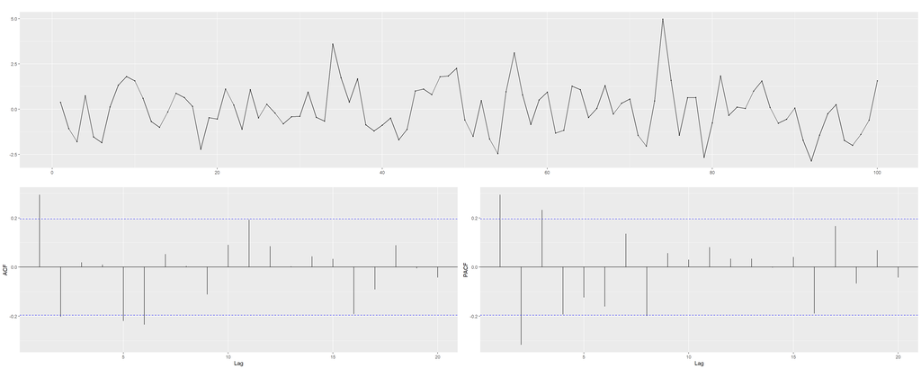

```r
par(mfrow = c(1,1))
ggtsdisplay(MA2)
```

#### Autoregressive AR(1):

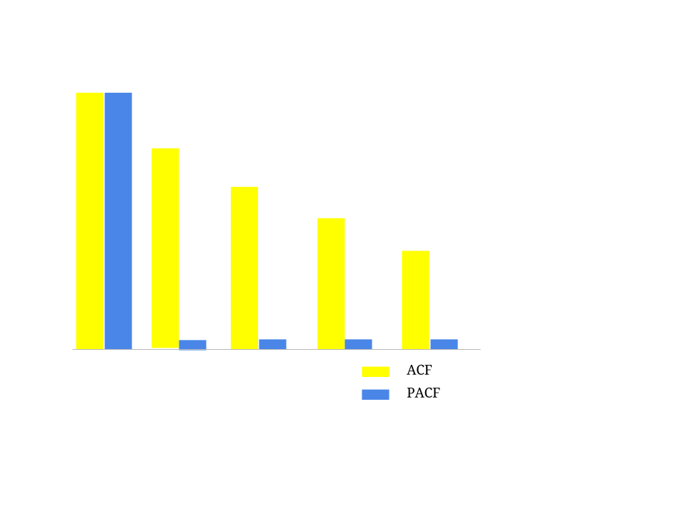

Here the ACF decays geometrically, and the PACF shows only one significant lag. This is a AR(1) process of the form: $\large \color{blue}{y_t} = c + \color{red}{\rho}\, \color{blue}{y_{t-1}}+\epsilon_t.$

Here is the simulation in R with $\rho = 0.9:$

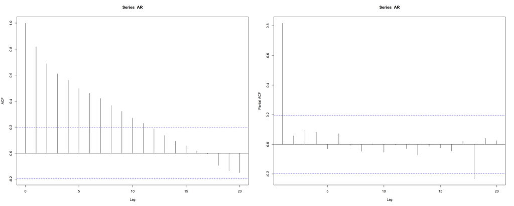

```r
set.seed(2017)
AR = arima.sim(model=list(ar = .9), n = 100)
par(mfrow = c(1,2));acf(AR);pacf(AR)
```

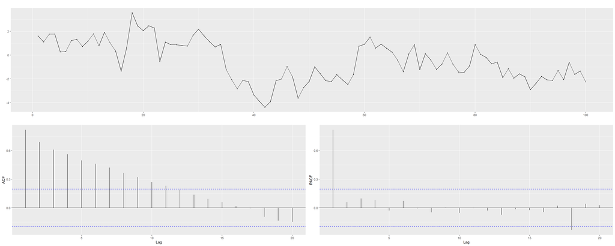

```r
ggtsdisplay(AR)
```

#### Autocorrelation AR(1) with faster decay:

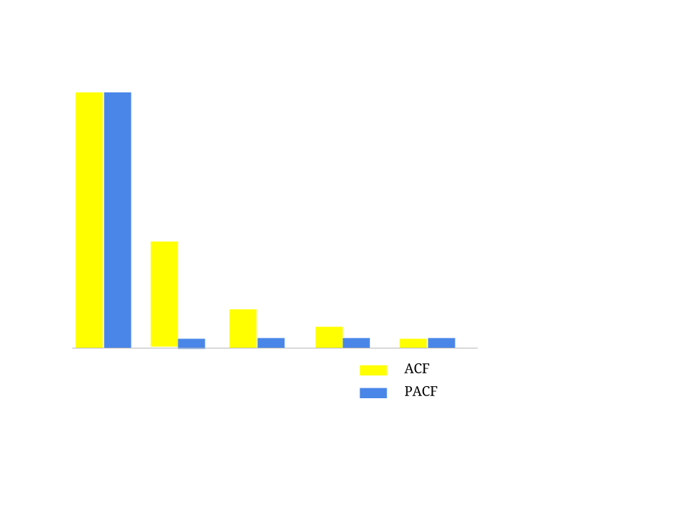

This is again an AR(1) process, but with a faster decay, $\rho=0.5:$

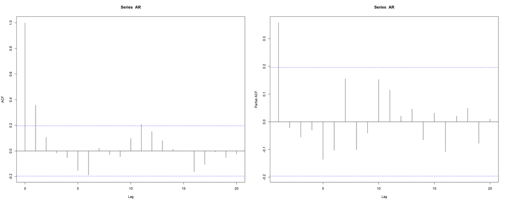

```r
set.seed(2017)
AR = arima.sim(model=list(ar = .5), n = 100)
par(mfrow = c(1,2));acf(AR);pacf(AR)
```

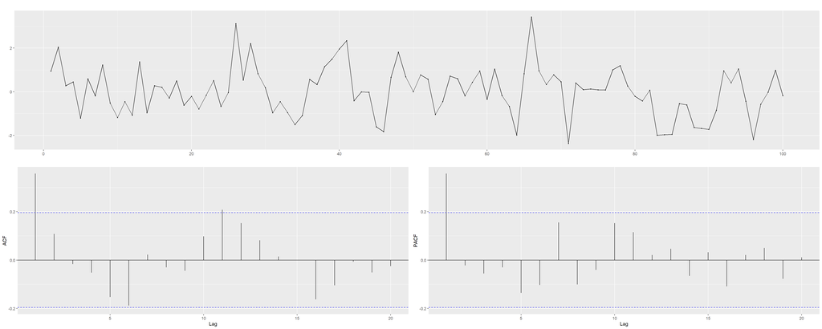

```r
ggtsdisplay(AR)
```

[Home Page](http://rinterested.github.io/statistics/index.html)

**NOTE: These are tentative notes on different topics for personal use - expect mistakes and misunderstandings.**